# 05c79d2236684859ba398c8796f71a8d

#**GLOBAL TERRORISM DATASET**

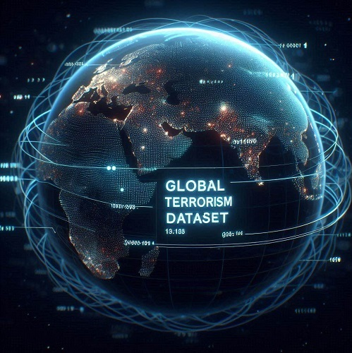

##### **Contribution** - Individual

##### **Project Owner -** Rijwan Adil Shaikh

# **Project Summary -**

####Code cell for Disclaimer of 1993. Code only for Pop up Messege, not for Project Purpose.

```python
from IPython.display import HTML, display

# Define the disclaimer
disclaimer = """
<div id='disclaimer' style='border: 1px solid #ccc; padding: 10px; margin-bottom: 20px;'>
    <strong>Disclaimer about 1993:</strong>
    <p>
        The GTD lacks most terrorism incidents from 1993 due to data loss prior to START’s compilation.
        Despite attempts to recover this data from original sources, only about 15% of estimated 1993 attacks
        were identified. To avoid misinterpretation, 1993 incidents are excluded from analysis.
        However, Appendix II provides country-level statistics based on early reports, and the limited
        1993 data is available for download on the GTD website.
    </p>
</div>
"""

# Display the disclaimer
#display(HTML(disclaimer))

# Add reference link in the chart explanation
ref_link = """
<p>
    The year 1993 is not visible in this chart due to data loss.
    <a href="#" onclick="event.preventDefault(); showAlert()">Click here</a> for more information.
</p>

<script>
    function showAlert() {
        alert('The GTD lacks most terrorism incidents from 1993 due to data loss prior to START’s compilation. Despite attempts to recover this data from original sources, only about 15% of estimated 1993 attacks were identified. To avoid misinterpretation, 1993 incidents are excluded from analysis. However, Appendix II provides country-level statistics based on early reports, and the limited 1993 data is available for download on the GTD website.');
    }
</script>
"""

# Display the reference link with pop-up functionality
#display(HTML(ref_link))
```

# **GitHub Link -**

Provide your GitHub Link here. https://github.com/Rijwan94/DS_Pyhton_M2/blob/main/Global_Terrorism_Dataset_EDA.ipynb

# **Problem Statement**

**The problem statement for the Exploratory Data Analysis (EDA) of the Global Terrorism Dataset is to analyze and uncover key patterns, trends, and anomalies within the data on terrorist incidents worldwide. This involves examining temporal trends, geographic distribution, and incident characteristics such as attack types, targets, and impacts. The goal is to identify significant patterns and insights, address data quality issues, and provide a comprehensive understanding of global terrorism dynamics to inform further analysis and decision-making.**

#### **The business objective**

The business objective of the Exploratory Data Analysis (EDA) on the Global Terrorism Dataset is to uncover actionable insights into global terrorism patterns. This analysis aims to identify key trends, hotspots, and characteristics of terrorist incidents to support strategic planning, risk assessment, and policy formulation for security agencies and policymakers, ultimately enhancing global counter-terrorism efforts.

# **General Guidelines** : -

1. Well-structured, formatted, and commented code is required.
2. Exception Handling, Production Grade Code & Deployment Ready Code will be a plus. Those students will be awarded some additional credits.

   The additional credits will have advantages over other students during Star Student selection.

   ```
       [ Note: - Deployment Ready Code is defined as, the whole .ipynb notebook should be executable in one go
                 without a single error logged. ]
   ```

3. Each and every logic should have proper comments.
4. You may add as many number of charts you want. Make Sure for each and every chart the following format should be answered.

```markdown
# Chart visualization code
```

- Why did you pick the specific chart?
- What is/are the insight(s) found from the chart?
- Will the gained insights help creating a positive business impact? Are there any insights that lead to negative growth? Justify with specific reason.
1. You have to create at least 20 logical & meaningful charts having important insights.

[ Hints : - Do the Vizualization in a structured way while following "UBM" Rule.

U - Univariate Analysis,

B - Bivariate Analysis (Numerical - Categorical, Numerical - Numerical, Categorical - Categorical)

M - Multivariate Analysis ]

# *Let's Begin !*

## *1. Know Your Data*

### Import Libraries

```python
# Import Libraries
import pandas as pd
import numpy as np
import matplotlib.pyplot as plt
import seaborn as sns
import plotly.express as px
import folium
from folium.plugins import HeatMap
import plotly.graph_objects as go
import matplotlib.colors as mcolors
```

### Dataset Loading

```python
# Load Dataset
from google.colab import drive
drive.mount('/content/drive')
```

```python
#Loading Gloabl Terrorism Database .csv file data into pandas dataframe called as 'global_td_df'
global_td_df = pd.read_csv('/content/drive/MyDrive/Data Science/Module_2 _Numerical_Programming_in_Python/Capstone Project/File_Global Terrorism Data.csv', encoding='latin-1')
```

### Dataset First View

```python
# Dataset First Look
global_td_df.head()
```

|  | eventid | iyear | imonth | iday | approxdate | extended | resolution | country | country_txt | region | ... | addnotes | scite1 | scite2 | scite3 | dbsource | INT_LOG | INT_IDEO | INT_MISC | INT_ANY | related |
| --- | --- | --- | --- | --- | --- | --- | --- | --- | --- | --- | --- | --- | --- | --- | --- | --- | --- | --- | --- | --- | --- |
| 0 | 197000000001 | 1970 | 7 | 2 | NaN | 0 | NaN | 58 | Dominican Republic | 2 | ... | NaN | NaN | NaN | NaN | PGIS | 0 | 0 | 0 | 0 | NaN |
| 1 | 197000000002 | 1970 | 0 | 0 | NaN | 0 | NaN | 130 | Mexico | 1 | ... | NaN | NaN | NaN | NaN | PGIS | 0 | 1 | 1 | 1 | NaN |
| 2 | 197001000001 | 1970 | 1 | 0 | NaN | 0 | NaN | 160 | Philippines | 5 | ... | NaN | NaN | NaN | NaN | PGIS | -9 | -9 | 1 | 1 | NaN |
| 3 | 197001000002 | 1970 | 1 | 0 | NaN | 0 | NaN | 78 | Greece | 8 | ... | NaN | NaN | NaN | NaN | PGIS | -9 | -9 | 1 | 1 | NaN |
| 4 | 197001000003 | 1970 | 1 | 0 | NaN | 0 | NaN | 101 | Japan | 4 | ... | NaN | NaN | NaN | NaN | PGIS | -9 | -9 | 1 | 1 | NaN |

5 rows × 135 columns

### Dataset Rows & Columns count

```python
# Dataset Rows & Columns count
global_td_df.shape
```

```
(181691, 135)
```

```python
numerical_columns = global_td_df.select_dtypes(include=['float64', 'int64'])

# Compute the correlation matrix
correlation_matrix = numerical_columns.corr()

# Convert the correlation matrix to a DataFrame
correlation_table = pd.DataFrame(correlation_matrix)

# Save the DataFrame to an Excel file
correlation_table.to_excel('correlation_matrix.xlsx', sheet_name='Correlation Matrix')
```

### Dataset Information

```python
# Dataset Info
global_td_df.info()
```

```
<class 'pandas.core.frame.DataFrame'>
RangeIndex: 181691 entries, 0 to 181690
Columns: 135 entries, eventid to related
dtypes: float64(55), int64(22), object(58)
memory usage: 187.1+ MB
```

### Creating New DataFrame **'gdt_df'** with Important Columns for analysis.

```python
# Listing out only important columns with new general term for user friendly understanding
column_renames = {'iyear': 'Year',
    'imonth': 'Month',
    'iday': 'Day',
    'country_txt': 'Country',
    'region_txt': 'Region',
    'provstate': 'Province/State',
    'city': 'City',
    'success': 'Success',
    'suicide': 'Suicide',
    'attacktype1_txt': 'Attack Type 1',
    'targtype1_txt': 'Target Type 1',
    'targsubtype1_txt': 'Target Subtype 1',
    'gname': 'Group Name 1',
    'motive': 'Motive',
    'claimmode_txt': 'Claim Mode',
    'weaptype1_txt': 'Weapon Type 1',
    'weapsubtype1_txt': 'Weapon Subtype 1',
    'nkill': 'Number Killed',
    'nwound': 'Number Wounded',
    'ishostkid': 'Is Hostage',
    'ransom': 'Ransom',
    'hostkidoutcome_txt': 'Hostage Outcome',
    'INT_LOG': 'Logistical Status',
    'INT_IDEO': 'Ideological Status'
}

# Rename columns
global_td_df.rename(columns=column_renames, inplace=True)
```

```python
#passing selected data to new df 'gtd_df'
gtd_df = global_td_df[['Year', 'Month', 'Day', 'Country', 'Region', 'Province/State',
                       'City','Success','Suicide', 'Attack Type 1', 'Target Type 1',
                       'Target Subtype 1','Group Name 1', 'Motive', 'Claim Mode',
                       'Weapon Type 1', 'Weapon Subtype 1', 'Number Killed', 'Number Wounded',
                       'Is Hostage', 'Ransom', 'Hostage Outcome', 'Logistical Status',
                       'Ideological Status']]
```

```python
# Dataset First Look of 'gtd_df'
gtd_df.head()
```

|  | Year | Month | Day | Country | Region | Province/State | City | Success | Suicide | Attack Type 1 | ... | Claim Mode | Weapon Type 1 | Weapon Subtype 1 | Number Killed | Number Wounded | Is Hostage | Ransom | Hostage Outcome | Logistical Status | Ideological Status |
| --- | --- | --- | --- | --- | --- | --- | --- | --- | --- | --- | --- | --- | --- | --- | --- | --- | --- | --- | --- | --- | --- |
| 0 | 1970 | 7 | 2 | Dominican Republic | Central America & Caribbean | NaN | Santo Domingo | 1 | 0 | Assassination | ... | NaN | Unknown | NaN | 1.0 | 0.0 | 0.0 | 0.0 | NaN | 0 | 0 |
| 1 | 1970 | 0 | 0 | Mexico | North America | Federal | Mexico city | 1 | 0 | Hostage Taking (Kidnapping) | ... | NaN | Unknown | NaN | 0.0 | 0.0 | 1.0 | 1.0 | NaN | 0 | 1 |
| 2 | 1970 | 1 | 0 | Philippines | Southeast Asia | Tarlac | Unknown | 1 | 0 | Assassination | ... | NaN | Unknown | NaN | 1.0 | 0.0 | 0.0 | 0.0 | NaN | -9 | -9 |
| 3 | 1970 | 1 | 0 | Greece | Western Europe | Attica | Athens | 1 | 0 | Bombing/Explosion | ... | NaN | Explosives | Unknown Explosive Type | NaN | NaN | 0.0 | 0.0 | NaN | -9 | -9 |
| 4 | 1970 | 1 | 0 | Japan | East Asia | Fukouka | Fukouka | 1 | 0 | Facility/Infrastructure Attack | ... | NaN | Incendiary | NaN | NaN | NaN | 0.0 | 0.0 | NaN | -9 | -9 |

5 rows × 24 columns

```python
# Dataset First Look of 'gtd_df'
gtd_df.tail()
```

|  | Year | Month | Day | Country | Region | Province/State | City | Success | Suicide | Attack Type 1 | ... | Claim Mode | Weapon Type 1 | Weapon Subtype 1 | Number Killed | Number Wounded | Is Hostage | Ransom | Hostage Outcome | Logistical Status | Ideological Status |
| --- | --- | --- | --- | --- | --- | --- | --- | --- | --- | --- | --- | --- | --- | --- | --- | --- | --- | --- | --- | --- | --- |
| 181686 | 2017 | 12 | 31 | Somalia | Sub-Saharan Africa | Middle Shebelle | Ceelka Geelow | 1 | 0 | Armed Assault | ... | Unknown | Firearms | Unknown Gun Type | 1.0 | 2.0 | 0.0 | NaN | NaN | 0 | 0 |
| 181687 | 2017 | 12 | 31 | Syria | Middle East & North Africa | Lattakia | Jableh | 1 | 0 | Bombing/Explosion | ... | NaN | Explosives | Projectile (rockets, mortars, RPGs, etc.) | 2.0 | 7.0 | 0.0 | NaN | NaN | -9 | -9 |
| 181688 | 2017 | 12 | 31 | Philippines | Southeast Asia | Maguindanao | Kubentog | 1 | 0 | Facility/Infrastructure Attack | ... | NaN | Incendiary | Arson/Fire | 0.0 | 0.0 | 0.0 | NaN | NaN | 0 | 0 |
| 181689 | 2017 | 12 | 31 | India | South Asia | Manipur | Imphal | 0 | 0 | Bombing/Explosion | ... | NaN | Explosives | Grenade | 0.0 | 0.0 | 0.0 | NaN | NaN | -9 | -9 |
| 181690 | 2017 | 12 | 31 | Philippines | Southeast Asia | Maguindanao | Cotabato City | 0 | 0 | Bombing/Explosion | ... | NaN | Explosives | Unknown Explosive Type | 0.0 | 0.0 | 0.0 | NaN | NaN | -9 | -9 |

5 rows × 24 columns

```python
# Dataset Rows & Columns count
gtd_df.shape
```

```
(181691, 24)
```

```python
# Dataset Info
gtd_df.info()
```

```
<class 'pandas.core.frame.DataFrame'>
RangeIndex: 181691 entries, 0 to 181690
Data columns (total 24 columns):
 #   Column              Non-Null Count   Dtype
---  ------              --------------   -----
 0   Year                181691 non-null  int64
 1   Month               181691 non-null  int64
 2   Day                 181691 non-null  int64
 3   Country             181691 non-null  object
 4   Region              181691 non-null  object
 5   Province/State      181270 non-null  object
 6   City                181256 non-null  object
 7   Success             181691 non-null  int64
 8   Suicide             181691 non-null  int64
 9   Attack Type 1       181691 non-null  object
```

[output cut: 16 more lines]

#### Duplicate Values

```python
# Dataset Duplicate Value Count
gtd_df.duplicated().sum()
```

```
12449
```

#### Missing Values/Null Values

```python
# Missing Values/Null Values Count
gtd_df.isnull().sum()
```

|  | 0 |
| --- | --- |
| Year | 0 |
| Month | 0 |
| Day | 0 |
| Country | 0 |
| Region | 0 |
| Province/State | 421 |
| City | 435 |
| Success | 0 |
| Suicide | 0 |
| Attack Type 1 | 0 |
| Target Type 1 | 0 |
| Target Subtype 1 | 10373 |
| Group Name 1 | 0 |
| Motive | 131130 |
| Claim Mode | 162608 |
| Weapon Type 1 | 0 |
| Weapon Subtype 1 | 20768 |
| Number Killed | 10313 |
| Number Wounded | 16311 |
| Is Hostage | 178 |
| Ransom | 104310 |
| Hostage Outcome | 170700 |
| Logistical Status | 0 |
| Ideological Status | 0 |

**dtype:** int64

###Visulizing NaN/Null Values

```python
#Visualization for  Number of Missing Values for Each Column

# Data
columns = [
    'Year', 'Month', 'Day', 'Country', 'Region', 'Province/State', 'City',
    'Success', 'Suicide', 'Attack Type 1', 'Target Type 1', 'Target Subtype 1',
    'Group Name 1', 'Motive', 'Claim Mode', 'Weapon Type 1', 'Weapon Subtype 1',
    'Number Killed', 'Number Wounded', 'Is Hostage', 'Ransom', 'Hostage Outcome',
    'Logistical Status', 'Ideological Status'
]
missing_values = [
    0, 0, 0, 0, 0, 421, 435, 0, 0, 0, 0, 10373, 0, 131130, 162608,
    0, 20768, 10313, 16311, 178, 104310, 170700, 0, 0
]

# Plot
fig, ax = plt.subplots(figsize=(12, 5))
bars = ax.bar(columns, missing_values, color='red')

# Adding labels and title
ax.set_xlabel('Columns')
ax.set_ylabel('Number of Missing Values')
ax.set_title('Number of Missing Values for Each Column')
ax.tick_params(axis='x', rotation=90)  # Rotate x-axis labels for better readability

# Adding value labels on bars
for bar in bars:
    height = bar.get_height()
    ax.text(bar.get_x() + bar.get_width() / 2.0, height, int(height),
            ha='center', va='bottom')

plt.tight_layout()
plt.show()
```

[figure not shown]

```python
# Fill NaN values in Province/State column as 'Unknown'
gtd_df['Province/State'] = gtd_df['Province/State'].fillna('Unknown')

# Fill NaN values in City column as 'Unknown'
gtd_df['City'] = gtd_df['City'].fillna('Unknown')

# Fill NaN values in Target Subtype 1 column as 'Unknown'
gtd_df['Target Subtype 1'] = gtd_df['Target Subtype 1'].fillna('Unknown')

# Fill NaN values in Motive column as 'Unknown'
gtd_df['Motive'] = gtd_df['Motive'].fillna('Unknown')

# Fill NaN values in Claim Mode column as 'Unknown'
gtd_df['Claim Mode'] = gtd_df['Claim Mode'].fillna('Unknown')

# Fill NaN values in Weapon Subtype 1 column as 'Unknown'
gtd_df['Weapon Subtype 1'] = gtd_df['Weapon Subtype 1'].fillna('Unknown')

# Fill NaN values in Number Killed column as 'Unknown'
gtd_df['Number Killed'] = gtd_df['Number Killed'].fillna('Unknown')

# Fill NaN values in Number Wounded column as 'Unknown'
gtd_df['Number Wounded'] = gtd_df['Number Wounded'].fillna('Unknown')

# Fill NaN values in Is Hostage column as 'Unknown'
gtd_df['Is Hostage'] = gtd_df['Is Hostage'].fillna('Unknown')

# Fill NaN values in Ransom column as 'Unknown'
gtd_df['Ransom'] = gtd_df['Ransom'].fillna('Not Applicable')

# Fill NaN values in Hostage Outcome column as 'Unknown'
gtd_df['Hostage Outcome'] = gtd_df['Hostage Outcome'].fillna('Unknown')
```

[output not shown]

[output cut: 32 more lines]

[output not shown]

NaN/Null Value Count after Removal

```python
#NaN/Null Values count after handling data
gtd_df.isnull().sum()
```

|  | 0 |
| --- | --- |
| Year | 0 |
| Month | 0 |
| Day | 0 |
| Country | 0 |
| Region | 0 |
| Province/State | 0 |
| City | 0 |
| Success | 0 |
| Suicide | 0 |
| Attack Type 1 | 0 |
| Target Type 1 | 0 |
| Target Subtype 1 | 0 |
| Group Name 1 | 0 |
| Motive | 0 |
| Claim Mode | 0 |
| Weapon Type 1 | 0 |
| Weapon Subtype 1 | 0 |
| Number Killed | 0 |
| Number Wounded | 0 |
| Is Hostage | 0 |
| Ransom | 0 |
| Hostage Outcome | 0 |
| Logistical Status | 0 |
| Ideological Status | 0 |

**dtype:** int64

### What did you know about your dataset?

The dataset contains 1,81,691 entries documenting terrorist attacks. we are taking 24 columns out of 135 columns into consideration for better and quick analysis. It includes key columns such as the date of the attack, location details (Country, Region, City), and attributes related to the attack's nature (Attack Type, Target Type, Group Name). While most columns are complete. Overall, the dataset offers a comprehensive view of terrorist activities with a lot of detailed information.

## *2. Understanding Your Variables*

```python
# Dataset Columns
gtd_df.columns
```

```
Index(['Year', 'Month', 'Day', 'Country', 'Region', 'Province/State', 'City',
       'Success', 'Suicide', 'Attack Type 1', 'Target Type 1',
       'Target Subtype 1', 'Group Name 1', 'Motive', 'Claim Mode',
       'Weapon Type 1', 'Weapon Subtype 1', 'Number Killed', 'Number Wounded',
       'Is Hostage', 'Ransom', 'Hostage Outcome', 'Logistical Status',
       'Ideological Status'],
      dtype='object')
```

```python
# Dataset Describe
gtd_df.describe()
```

|  | Year | Month | Day | Success | Suicide | Logistical Status | Ideological Status |
| --- | --- | --- | --- | --- | --- | --- | --- |
| count | 181691.000000 | 181691.000000 | 181691.000000 | 181691.000000 | 181691.000000 | 181691.000000 | 181691.000000 |
| mean | 2002.638997 | 6.467277 | 15.505644 | 0.889598 | 0.036507 | -4.543731 | -4.464398 |
| std | 13.259430 | 3.388303 | 8.814045 | 0.313391 | 0.187549 | 4.543547 | 4.637152 |
| min | 1970.000000 | 0.000000 | 0.000000 | 0.000000 | 0.000000 | -9.000000 | -9.000000 |
| 25% | 1991.000000 | 4.000000 | 8.000000 | 1.000000 | 0.000000 | -9.000000 | -9.000000 |
| 50% | 2009.000000 | 6.000000 | 15.000000 | 1.000000 | 0.000000 | -9.000000 | -9.000000 |
| 75% | 2014.000000 | 9.000000 | 23.000000 | 1.000000 | 0.000000 | 0.000000 | 0.000000 |
| max | 2017.000000 | 12.000000 | 31.000000 | 1.000000 | 1.000000 | 1.000000 | 1.000000 |

### Check Unique Values for each variable.

```python
# Check Unique Values for each variable.
for column in gtd_df.columns:
    unique_values = gtd_df[column].unique()
    print(f"Unique values for column '{column}':")
    print(unique_values)
    print()
```

```
Unique values for column 'Year':
[1970 1971 1972 1973 1974 1975 1976 1977 1978 1979 1980 1981 1986 1982
 1983 1984 1985 1987 1988 1989 1990 1991 1992 1994 1995 1996 1997 1998
 1999 2000 2001 2002 2003 2004 2005 2006 2007 2008 2009 2010 2011 2012
 2013 2014 2015 2016 2017]

Unique values for column 'Month':
[ 7  0  1  2  3  4  5  6  8  9 10 11 12]

Unique values for column 'Day':
[ 2  0  1  3  6  8  9 10 11 12 13 14 15 19 20 21 22 25 26 27 28 30 31  4
  7 16 17 18 23 24  5 29]

Unique values for column 'Country':
['Dominican Republic' 'Mexico' 'Philippines' 'Greece' 'Japan'
 'United States' 'Uruguay' 'Italy' 'East Germany (GDR)' 'Ethiopia'
 'Guatemala' 'Venezuela' 'West Germany (FRG)' 'Switzerland' 'Jordan'
 'Spain' 'Brazil' 'Egypt' 'Argentina' 'Lebanon' 'Ireland' 'Turkey'
 'Paraguay' 'Iran' 'United Kingdom' 'Colombia' 'Bolivia' 'Nicaragua'
 'Netherlands' 'Belgium' 'Canada' 'Australia' 'Pakistan' 'Zambia' 'Sweden'
 'Costa Rica' 'South Yemen' 'Cambodia' 'Israel' 'Poland' 'Taiwan' 'Panama'
 'Kuwait' 'West Bank and Gaza Strip' 'Austria' 'Czechoslovakia' 'India'
 'France' 'South Vietnam' 'Brunei' 'Zaire'
 "People's Republic of the Congo" 'Portugal' 'Algeria' 'El Salvador'
 'Thailand' 'Haiti' 'Sudan' 'Morocco' 'Cyprus' 'Myanmar' 'Afghanistan'
 'Peru' 'Chile' 'Honduras' 'Yugoslavia' 'Ecuador' 'New Zealand' 'Malaysia'
 'Singapore' 'Botswana' 'Jamaica' 'Chad' 'North Yemen' 'Andorra' 'Syria'
 'South Korea' 'United Arab Emirates' 'South Africa' 'Kenya' 'Iraq'
 'Somalia' 'Tanzania' 'Sri Lanka' 'Namibia' 'Bahamas' 'Nigeria' 'Barbados'
 'Trinidad and Tobago' 'Bangladesh' 'Angola' 'Mauritania' 'Saudi Arabia'
 'Djibouti' 'Indonesia' 'Malta' 'Rhodesia' 'Soviet Union' 'Denmark'
 'Western Sahara' 'Guyana' 'Mozambique' 'Tunisia' 'Uganda' 'Norway'
 'Lesotho' 'Gabon' 'Libya' 'Bahrain' 'Hong Kong' 'Senegal' 'Zimbabwe'
 'Guinea' 'Grenada' 'New Hebrides' 'Belize' 'Guadeloupe' 'Martinique'
 'Vatican City' 'Albania' 'Central African Republic' 'Seychelles'
 'Dominica' 'Qatar' 'Bulgaria' 'Suriname' 'Swaziland' 'Luxembourg'
 'Iceland' 'French Guiana' 'Falkland Islands' 'Burkina Faso'
 'New Caledonia' 'Romania' 'Niger' 'Nepal' 'Togo' 'Finland' 'Fiji' 'Ghana'
 'Maldives' 'Mauritius' 'Hungary' 'Laos' 'Papua New Guinea' 'China'
 'Liberia' 'Republic of the Congo' 'Mali' 'Germany' 'Yemen' 'Rwanda'
```

[output cut: 172 more lines]

```

Unique values for column 'Ransom':
[0.0 1.0 'Not Applicable' -9.0]

Unique values for column 'Hostage Outcome':
['Unknown' 'Hostage(s) released by perpetrators' 'Successful Rescue'
 'Hostage(s) killed (not during rescue attempt)'
 'Hostage(s) escaped (not during rescue attempt)' 'Combination'
 'Attempted Rescue']

Unique values for column 'Logistical Status':
[ 0 -9  1]

Unique values for column 'Ideological Status':
[ 0  1 -9]
```

## 3. *Data Wrangling*

### Data Wrangling Code

```python
#Data Wrangling Code - EDA - Global Terrorism Dataset
class TerrorismWrangling:
    def __init__(self, gtd_df):
        """Initialize with dataframe."""
        try:
            self.df = gtd_df.copy()
            # Convert columns to appropriate data types
            self.df['Year'] = self.df['Year'].astype(int)

            # Handle non-numeric values in 'Ransom' before conversion
            self.df['Ransom'] = self.df['Ransom'].replace('Not Applicable', '-9')
            self.df['Ransom'] = self.df['Ransom'].fillna(-9).astype(float)  # Handle 'Unknown' cases

            # Handle 'Unknown' values in 'Is Hostage' before conversion
            self.df['Is Hostage'] = self.df['Is Hostage'].replace('Unknown', '-9') # Replace 'Unknown' with '-9'
            self.df['Is Hostage'] = self.df['Is Hostage'].fillna(-9).astype(int)  # Handle remaining missing values

            # Map values to descriptive strings
            self.df['Ransom'] = self.df['Ransom'].map({1: 'Yes', 0: 'No', -9: 'Unknown'})
            self.df['Is Hostage'] = self.df['Is Hostage'].map({1: 'Yes', 0: 'No', -9: 'Unknown'})
        except Exception as e:
            raise ValueError(f'Error initializing: {e}')

    def get_df(self):
        """Returns the dataframe."""
        return self.df

    def incedent_by_Years(self):
        """Returns number of incidents per year."""
        return self.df['Year'].value_counts().sort_index()

    def types_of_attack(self):
        """Returns top attack types."""
        return self.df['Attack Type 1'].value_counts().sort_values(ascending=False)

    def types_of_target(self):
        """Returns top target types."""
        return self.df['Target Type 1'].value_counts().sort_values(ascending=False)

    def top_terrorist_group(self):
        """Returns top terrorist groups."""
        return self.df['Group Name 1'].value_counts().sort_values(ascending=False)

    def avg_number_killed(self):
        """Returns average number killed."""
        return self.df['Number Killed'].mean()

    def avg_number_wounded(self):
        """Returns average number wounded."""
        return self.df['Number Wounded'].mean()

    def Incident_with_ransom(self):
        """Returns total count of incidents involving ransom demands."""
        return (self.df['Ransom'] == 'Yes').sum()

    def incidents_with_hostages(self):
        """Returns number of incidents with hostages."""
        return (self.df['Is Hostage'] == 'Yes').sum()

    def incidents_by_country(self, top_n=30):
        """Returns number of incidents per country."""
        return self.df['Country'].value_counts().head(top_n)

    def incidents_by_region(self, top_n=15):
        """Returns number of incidents per region."""
        return self.df['Region'].value_counts().head(top_n)

    def incidents_by_city(self, top_n=15):
        """Returns number of incidents per city."""
        return self.df['City'].value_counts().head(top_n)

    def incidents_by_month(self):
        """Returns number of incidents by month."""
        # Convert 'Month' column to numeric, handling non-numeric values
        self.df['Month'] = pd.to_numeric(self.df['Month'], errors='coerce')

        # Count attacks by month
        month_counts = self.df['Month'].value_counts().sort_index()

        # Ensure all months from 0 to 12 are represented, including months with zero counts
        full_month_counts = month_counts.reindex(range(0, 13), fill_value=0)

        return full_month_counts

    def incidents_by_attack_type(self):
        """Returns number of incidents per attack type."""
        return self.df['Attack Type 1'].value_counts().sort_values(ascending=False)

    def incidents_specific_attack_type(self, attack_type):
        """Returns dataframe with specific attack type."""
        return self.df[self.df['Attack Type 1'] == attack_type]

    def incidents_by_target_type(self):
        """Returns number of incidents per target type."""
        return self.df['Target Type 1'].value_counts().sort_values(ascending=False)

    def incidents_specific_target_type(self, target_type):
        """Returns dataframe with specific target type."""
        return self.df[self.df['Target Type 1'] == target_type]

    def incidents_by_year_month(self):
        """Returns number of incidents by year and month."""
        return self.df.groupby(['Year', 'Month']).size()

    def get_df_with_text_length(self):
        """Returns dataframe with text length of summaries."""
        self.df['Motive Length'] = self.df['Motive'].apply(lambda x: len(x) if pd.notna(x) else 0)
        return self.df

    def incidents_Specific_terrorist_group(self, group_name):
        """Returns dataframe with specific terrorist group."""
        return self.df[self.df['Group Name 1'] == group_name]

    def attack_by_region_sorted(self):
        """Returns number of incidents per region sorted by frequency."""
        return self.df['Region'].value_counts().sort_values(ascending=False)

    def incidents_by_region_count(self):
        """Returns count of incidents by region."""
        return self.df['Region'].value_counts()

    def frequent_regions(self, min_count):
        """Returns regions with more than min_count incidents."""
        return self.df['Region'].value_counts()[self.df['Region'].value_counts() > min_count]

    def count_attacks_by_country(self, top_n=30):
        """Returns the count of attacks by country."""
        return self.df['Country'].value_counts().head(top_n)

    def count_attacks_by_city(self, top_n=15):
        """Returns the count of attacks by city."""
        return self.df['City'].value_counts().head(top_n)

    def count_attacks_by_year(self):
        """Returns the count of attacks by year."""
        return self.df['Year'].value_counts().sort_index()

    def count_attacks_by_month(self):
        """Returns the count of attacks by month, sorted in ascending order."""
        # Convert 'Month' column to numeric, handling non-numeric values
        self.df['Month'] = pd.to_numeric(self.df['Month'], errors='coerce')
```

```python
        # Count attacks by month
        month_counts = self.df['Month'].value_counts().sort_index()

        # Ensure all months from 0 to 12 are represented, including months with zero counts
        full_month_counts = month_counts.reindex(range(0, 13), fill_value=0)

        return full_month_counts

    def count_attack_types(self, top_n=15):
        """Returns the count of attack types."""
        return self.df['Attack Type 1'].value_counts().head(top_n)

    def count_target_types(self, top_n=15):
        """Returns the count of target types."""
        return self.df['Target Type 1'].value_counts().head(top_n)

    def count_terrorist_groups(self, top_n=15):
        """Returns the count of terrorist groups."""
        return self.df['Group Name 1'].value_counts().head(top_n)

    def total_fatalities(self):
        """Returns the total number of fatalities."""
        self.df['Number Killed'] = pd.to_numeric(self.df['Number Killed'], errors='coerce')
        return self.df['Number Killed'].sum()

    def total_injuries(self):
        """Returns the total number of injuries."""
        self.df['Number Wounded'] = pd.to_numeric(self.df['Number Wounded'], errors='coerce')
        return self.df['Number Wounded'].sum()

    def avg_fatalities_per_attack(self):
        """Returns the average number of fatalities per attack."""
        return self.df['Number Killed'].mean()

    def avg_injuries_per_attack(self):
        """Returns the average number of injuries per attack."""
        return self.df['Number Wounded'].mean()

    def count_incidents_with_hostages(self):
        """Returns the count of incidents with hostages."""
        return (self.df['Is Hostage'] == 'Yes').sum()

    def count_incidents_with_ransom(self):
        """Returns the count of incidents with ransom demands."""
        return (self.df['Ransom'] == 'Yes').sum()

    def count_unknown_groups_per_year(self):
        """Returns the count of 'Unknown' group names per year in descending order."""
        try:
            unknown_counts = self.df[self.df['Group Name 1'] == 'Unknown'].groupby('Year').size()
            return unknown_counts.sort_values(ascending=False)
        except Exception as e:
            raise ValueError(f'Error occurred: {e}')

    def percentage_unknown_groups_per_year(self):
        """Returns the percentage of unknown group attacks by year."""
        try:
            # Count unknown group attacks per year
            unknown_counts = self.df[self.df['Group Name 1'] == 'Unknown'].groupby('Year').size()

            # Count total attacks per year
            total_attacks = self.df.groupby('Year').size()

            # Calculate the percentage of unknown group attacks
            percentage_unknown = (unknown_counts / total_attacks * 100).fillna(0)

            return percentage_unknown.sort_index()  # Return in ascending order by year
        except Exception as e:
            raise ValueError(f'Error occurred: {e}')

    def active_years_of_top_20_groups(self):
        """Returns the top 20 terrorist groups with the highest number of incidents and their number of active years."""
        try:
            # Filter out 'Unknown' groups
            known_groups_df = self.df[self.df['Group Name 1'] != 'Unknown']

            # Count incidents per terrorist group
            group_incident_counts = known_groups_df['Group Name 1'].value_counts()

            # Get the top 20 groups by number of incidents
            top_20_groups = group_incident_counts.head(20).index

            # Count active years for each of these top 20 groups
            active_years = known_groups_df[known_groups_df['Group Name 1'].isin(top_20_groups)].groupby('Group Name 1')['Year'].nunique()

            # Combine the incident counts and active years into a DataFrame for better readability
            top_20_summary = pd.DataFrame({
                'Number of Incidents': group_incident_counts.loc[top_20_groups],
                'Active Years': active_years
            }).sort_values(by='Number of Incidents', ascending=False)

            # Return only the 'Active Years' for top 20 groups
            return top_20_summary[['Active Years']]

        except Exception as e:
            raise ValueError(f'Error occurred: {e}')


    def highest_groups_logistical_status(self):
        """Find the groups with the highest number of incidents where Logistical Status is 1."""
        try:
            # Filter the DataFrame for Logistical Status 1
            logistical_df = self.df[self.df['Logistical Status'] == 1]

            # Count incidents per terrorist group
            group_incident_counts = logistical_df['Group Name 1'].value_counts()

            return group_incident_counts

        except Exception as e:
            raise ValueError(f'Error occurred: {e}')

    def attacks_by_group_ideological_status(self):
        """Find the number of attacks for each group with Ideological Status as 1."""
        try:
            # Filter the DataFrame for Ideological Status 1
            ideological_df = self.df[self.df['Ideological Status'] == 1]

            # Group by 'Group Name 1' and count the number of attacks
            attacks_by_group = ideological_df.groupby('Group Name 1').size()

            # Sort the results to find the groups with the highest number of attacks
            sorted_attacks = attacks_by_group.sort_values(ascending=False)

            return sorted_attacks

        except Exception as e:
            raise ValueError(f'Error occurred: {e}')


gtd = TerrorismWrangling(gtd_df)

#Usage Example:

#gtd.Incident_with_ransom
#gtd.incidents_with_hostages()
#gtd.incidents_by_country()
#gtd.incidents_by_region()
#gtd.incidents_by_city()
#gtd.incidents_by_month()
#gtd.incidents_by_attack_type()
#gtd.incidents_by_target_type()
#gtd.incidents_by_year_month()
#gtd.get_df_with_text_length()
#gtd.incidents_Specific_terrorist_group('Taliban')
#gtd.attack_by_region_sorted()
#gtd.incidents_by_region_count()
#gtd.frequent_regions(100)
#gtd.count_attacks_by_country()
#gtd.count_attacks_by_city()
#gtd.count_attacks_by_year()
#gtd.count_attacks_by_month()
#gtd.count_attack_types()
#gtd.count_target_types()
#gtd.count_terrorist_groups()
#gtd.total_fatalities()
#gtd.total_injuries()
#gtd.avg_fatalities_per_attack()
#gtd.avg_injuries_per_attack()
#gtd.count_incidents_with_hostages()
#gtd.count_incidents_with_ransom()
#gtd.count_unknown_groups_per_year()
#gtd.percentage_unknown_groups_per_year()
#gtd.active_years_of_top_20_groups()
#gtd.highest_groups_logistical_status()
#gtd.attacks_by_group_ideological_status()
#gtd.get_df()
```

```python
# Count of attacks by country
gtd.count_attacks_by_country()
```

| Country | count |
| --- | --- |
| Iraq | 24636 |
| Pakistan | 14368 |
| Afghanistan | 12731 |
| India | 11960 |
| Colombia | 8306 |
| Philippines | 6908 |
| Peru | 6096 |
| El Salvador | 5320 |
| United Kingdom | 5235 |
| Turkey | 4292 |
| Somalia | 4142 |
| Nigeria | 3907 |
| Thailand | 3849 |
| Yemen | 3347 |
| Spain | 3249 |
| Sri Lanka | 3022 |
| United States | 2836 |
| Algeria | 2743 |
| France | 2693 |
| Egypt | 2479 |
| Lebanon | 2478 |
| Chile | 2365 |
| Libya | 2249 |
| West Bank and Gaza Strip | 2227 |
| Syria | 2201 |
| Russia | 2194 |
| Israel | 2183 |
| Guatemala | 2050 |
| South Africa | 2016 |
| Nicaragua | 1970 |

**dtype:** int64

```python
# Count of attacks by region
gtd.attack_by_region_sorted().head(15)
```

| Region | count |
| --- | --- |
| Middle East & North Africa | 50474 |
| South Asia | 44974 |
| South America | 18978 |
| Sub-Saharan Africa | 17550 |
| Western Europe | 16639 |
| Southeast Asia | 12485 |
| Central America & Caribbean | 10344 |
| Eastern Europe | 5144 |
| North America | 3456 |
| East Asia | 802 |
| Central Asia | 563 |
| Australasia & Oceania | 282 |

**dtype:** int64

```python
# Count of attacks by city
gtd.count_attacks_by_city().head(15)
```

| City | count |
| --- | --- |
| Unknown | 10210 |
| Baghdad | 7589 |
| Karachi | 2652 |
| Lima | 2359 |
| Mosul | 2265 |
| Belfast | 2171 |
| Santiago | 1621 |
| Mogadishu | 1581 |
| San Salvador | 1558 |
| Istanbul | 1048 |
| Athens | 1019 |
| Bogota | 984 |
| Kirkuk | 925 |
| Beirut | 918 |
| Medellin | 848 |

**dtype:** int64

```python
# Count of attacks by year
gtd.count_attacks_by_year()
```

| Year | count |
| --- | --- |
| 1970 | 651 |
| 1971 | 471 |
| 1972 | 568 |
| 1973 | 473 |
| 1974 | 581 |
| 1975 | 740 |
| 1976 | 923 |
| 1977 | 1319 |
| 1978 | 1526 |
| 1979 | 2662 |
| 1980 | 2662 |
| 1981 | 2586 |
| 1982 | 2544 |
| 1983 | 2870 |
| 1984 | 3495 |
| 1985 | 2915 |
| 1986 | 2860 |
| 1987 | 3183 |
| 1988 | 3721 |
| 1989 | 4324 |
| 1990 | 3887 |
| 1991 | 4683 |
| 1992 | 5071 |
| 1994 | 3456 |
| 1995 | 3081 |
| 1996 | 3058 |
| 1997 | 3197 |
| 1998 | 934 |
| 1999 | 1395 |
| 2000 | 1814 |
| 2001 | 1906 |
| 2002 | 1333 |
| 2003 | 1278 |
| 2004 | 1166 |
| 2005 | 2017 |
| 2006 | 2758 |
| 2007 | 3242 |
| 2008 | 4805 |
| 2009 | 4721 |
| 2010 | 4826 |
| 2011 | 5076 |
| 2012 | 8522 |
| 2013 | 12036 |
| 2014 | 16903 |
| 2015 | 14965 |
| 2016 | 13587 |
| 2017 | 10900 |

**dtype:** int64

```python
# Count of attacks by month

#  0 indicates that the month is unknown for these attacks.
gtd.count_attacks_by_month()
```

| Month | count |
| --- | --- |
| 0 | 20 |
| 1 | 14936 |
| 2 | 13879 |
| 3 | 15257 |
| 4 | 15152 |
| 5 | 16875 |
| 6 | 15359 |
| 7 | 16268 |
| 8 | 15800 |
| 9 | 14180 |
| 10 | 15563 |
| 11 | 14906 |
| 12 | 13496 |

**dtype:** int64

```python
# Count of attack types
gtd.types_of_attack().head(15)
```

| Attack Type 1 | count |
| --- | --- |
| Bombing/Explosion | 88255 |
| Armed Assault | 42669 |
| Assassination | 19312 |
| Hostage Taking (Kidnapping) | 11158 |
| Facility/Infrastructure Attack | 10356 |
| Unknown | 7276 |
| Unarmed Assault | 1015 |
| Hostage Taking (Barricade Incident) | 991 |
| Hijacking | 659 |

**dtype:** int64

```python
# Count of target types
gtd.types_of_target().head(15)
```

| Target Type 1 | count |
| --- | --- |
| Private Citizens & Property | 43511 |
| Military | 27984 |
| Police | 24506 |
| Government (General) | 21283 |
| Business | 20669 |
| Transportation | 6799 |
| Utilities | 6023 |
| Unknown | 5898 |
| Religious Figures/Institutions | 4440 |
| Educational Institution | 4322 |
| Government (Diplomatic) | 3573 |
| Terrorists/Non-State Militia | 3039 |
| Journalists & Media | 2948 |
| Violent Political Party | 1866 |
| Airports & Aircraft | 1343 |

**dtype:** int64

```python
# Count of terrorist groups
gtd.top_terrorist_group().head(21)
```

| Group Name 1 | count |
| --- | --- |
| Unknown | 82782 |
| Taliban | 7478 |
| Islamic State of Iraq and the Levant (ISIL) | 5613 |
| Shining Path (SL) | 4555 |
| Farabundo Marti National Liberation Front (FMLN) | 3351 |
| Al-Shabaab | 3288 |
| New People's Army (NPA) | 2772 |
| Irish Republican Army (IRA) | 2671 |
| Revolutionary Armed Forces of Colombia (FARC) | 2487 |
| Boko Haram | 2418 |
| Kurdistan Workers' Party (PKK) | 2310 |
| Basque Fatherland and Freedom (ETA) | 2024 |
| Communist Party of India - Maoist (CPI-Maoist) | 1878 |
| Maoists | 1630 |
| Liberation Tigers of Tamil Eelam (LTTE) | 1606 |
| National Liberation Army of Colombia (ELN) | 1561 |
| Tehrik-i-Taliban Pakistan (TTP) | 1351 |
| Palestinians | 1125 |
| Houthi extremists (Ansar Allah) | 1062 |
| Al-Qaida in the Arabian Peninsula (AQAP) | 1020 |
| Nicaraguan Democratic Force (FDN) | 895 |

**dtype:** int64

```python
# Number of untracked Group of terrorist per year
gtd.count_unknown_groups_per_year()
```

| Year | 0 |
| --- | --- |
| 2014 | 8813 |
| 2013 | 7973 |
| 2015 | 6397 |
| 2016 | 5969 |
| 2012 | 4826 |
| 2017 | 4349 |
| 2011 | 3175 |
| 2008 | 2990 |
| 2009 | 2916 |
| 2010 | 2906 |
| 2007 | 2171 |
| 1997 | 1958 |
| 1992 | 1822 |
| 2006 | 1762 |
| 1996 | 1592 |
| 1995 | 1572 |
| 1994 | 1464 |
| 1991 | 1388 |
| 1990 | 1230 |
| 1981 | 1222 |
| 1980 | 1217 |
| 1989 | 1184 |
| 2005 | 1068 |
| 1984 | 1023 |
| 1982 | 998 |
| 1988 | 977 |
| 1986 | 826 |
| 1979 | 799 |
| 2001 | 798 |
| 2000 | 710 |
| 1983 | 704 |
| 1985 | 684 |
| 1987 | 657 |
| 1999 | 640 |
| 2004 | 607 |
| 1977 | 520 |
| 1978 | 499 |
| 2003 | 492 |
| 2002 | 477 |
| 1998 | 463 |
| 1976 | 303 |
| 1975 | 128 |
| 1974 | 115 |
| 1970 | 115 |
| 1973 | 112 |
| 1971 | 98 |
| 1972 | 73 |

**dtype:** int64

```python
#Percentage of Unknown attackers as compare to attacked incidents
gtd.percentage_unknown_groups_per_year()
```

| Year | 0 |
| --- | --- |
| 1970 | 17.665131 |
| 1971 | 20.806794 |
| 1972 | 12.852113 |
| 1973 | 23.678647 |
| 1974 | 19.793460 |
| 1975 | 17.297297 |
| 1976 | 32.827736 |
| 1977 | 39.423806 |
| 1978 | 32.699869 |
| 1979 | 30.015026 |
| 1980 | 45.717506 |
| 1981 | 47.254447 |
| 1982 | 39.229560 |
| 1983 | 24.529617 |
| 1984 | 29.270386 |
| 1985 | 23.464837 |
| 1986 | 28.881119 |
| 1987 | 20.640905 |
| 1988 | 26.256383 |
| 1989 | 27.382054 |
| 1990 | 31.643941 |
| 1991 | 29.639120 |
| 1992 | 35.929797 |
| 1994 | 42.361111 |
| 1995 | 51.022395 |
| 1996 | 52.060170 |
| 1997 | 61.244917 |
| 1998 | 49.571734 |
| 1999 | 45.878136 |
| 2000 | 39.140022 |
| 2001 | 41.867786 |
| 2002 | 35.783946 |
| 2003 | 38.497653 |
| 2004 | 52.058319 |
| 2005 | 52.949926 |
| 2006 | 63.886875 |
| 2007 | 66.964837 |
| 2008 | 62.226847 |
| 2009 | 61.766575 |
| 2010 | 60.215499 |
| 2011 | 62.549251 |
| 2012 | 56.629899 |
| 2013 | 66.242938 |
| 2014 | 52.138674 |
| 2015 | 42.746408 |
| 2016 | 43.931699 |
| 2017 | 39.899083 |

**dtype:** float64

```python
#Active Years of Top 20 Terrorist Groups
gtd.active_years_of_top_20_groups()
```

| Group Name 1 | Active Years |
| --- | --- |
| Taliban | 18 |
| Islamic State of Iraq and the Levant (ISIL) | 5 |
| Shining Path (SL) | 36 |
| Farabundo Marti National Liberation Front (FMLN) | 15 |
| Al-Shabaab | 11 |
| New People's Army (NPA) | 42 |
| Irish Republican Army (IRA) | 36 |
| Revolutionary Armed Forces of Colombia (FARC) | 41 |
| Boko Haram | 9 |
| Kurdistan Workers' Party (PKK) | 31 |
| Basque Fatherland and Freedom (ETA) | 41 |
| Communist Party of India - Maoist (CPI-Maoist) | 13 |
| Maoists | 24 |
| Liberation Tigers of Tamil Eelam (LTTE) | 29 |
| National Liberation Army of Colombia (ELN) | 43 |
| Tehrik-i-Taliban Pakistan (TTP) | 11 |
| Palestinians | 28 |
| Houthi extremists (Ansar Allah) | 9 |
| Al-Qaida in the Arabian Peninsula (AQAP) | 11 |
| Nicaraguan Democratic Force (FDN) | 5 |

```python
#Top Groups with highest count for logistically international Attacks
gtd.highest_groups_logistical_status().head(15)
```

| Group Name 1 | count |
| --- | --- |
| Palestinians | 636 |
| Al-Shabaab | 418 |
| Irish Republican Army (IRA) | 375 |
| Boko Haram | 331 |
| Corsican National Liberation Front (FLNC) | 209 |
| Hamas (Islamic Resistance Movement) | 204 |
| Kurdistan Workers' Party (PKK) | 201 |
| Hizbul Mujahideen (HM) | 194 |
| Islamic State of Iraq and the Levant (ISIL) | 193 |
| Lord's Resistance Army (LRA) | 192 |
| Lashkar-e-Taiba (LeT) | 185 |
| Armenian Secret Army for the Liberation of Armenia | 169 |
| Houthi extremists (Ansar Allah) | 154 |
| Palestinian Islamic Jihad (PIJ) | 134 |
| Black September | 106 |

**dtype:** int64

```python
##Top Groups with highest count for Ideaologically international Attacks
gtd.attacks_by_group_ideological_status().head(15)
```

| Group Name 1 | 0 |
| --- | --- |
| Islamic State of Iraq and the Levant (ISIL) | 5613 |
| Basque Fatherland and Freedom (ETA) | 2024 |
| Al-Shabaab | 1175 |
| Al-Qaida in the Arabian Peninsula (AQAP) | 1020 |
| Taliban | 1004 |
| Donetsk People's Republic | 624 |
| Hezbollah | 406 |
| Boko Haram | 357 |
| Khorasan Chapter of the Islamic State | 343 |
| Al-Gama'at al-Islamiyya (IG) | 259 |
| Tamils | 217 |
| Allied Democratic Forces (ADF) | 216 |
| Houthi extremists (Ansar Allah) | 209 |
| Luhansk People's Republic | 209 |
| Lord's Resistance Army (LRA) | 201 |

**dtype:** int64

```python
# Total number of fatalities
gtd.total_fatalities()
```

```
411868.0
```

```python
# Total number of injuries
gtd.total_injuries()
```

```
523869.0
```

```python
# Average number of fatalities per attack
gtd.avg_number_killed()
```

```
2.4032722986614385
```

```python
# Average number of injuries per attack
gtd.avg_number_wounded()
```

```
3.1676684000483735
```

```python
# Count of incidents with hostages
gtd.incidents_with_hostages()
```

```
13572
```

```python
# Count of incidents with ransom
gtd.Incident_with_ransom()
```

```
1299
```

### What all manipulations have you done and insights you found?

**From analyzing the Global Terrorism Dataset from 1970 to 2017, we performed several data manipulations to extract key insights. We categorized and counted attacks by region, year, city, and type, and examined the types of targets and terrorist groups involved.**

**On a country level, Iraq had the highest number of attacks at 24,636, with Pakistan at 14,368 and Afghanistan at 12,731. Among cities, Baghdad was most frequently targeted with 7,589 attacks, Karachi had 2,652, and Lima had 2,359.**

**Regarding attack types, bombings/explosions were the most prevalent, comprising 88,255 incidents, followed by armed assaults with 42,669 incidents and assassinations with 19,312 incidents. The most common targets were private citizens and property (43,511 attacks), followed by military (27,984) and police (24,506).**

**In terms of terrorist groups, the majority of attacks (82,782) were attributed to unknown groups. Among identified groups, the Taliban was responsible for 7,478 attacks, while the Islamic State of Iraq and the Levant (ISIL) accounted for 5,613 attacks.**

**Overall, we found a total of 411,868 fatalities and 523,869 injuries across all incidents. The average number of people killed per incident was 2.4, and the average number wounded was 3.2. Additionally, there were 13,572 incidents involving hostages, with 1,299 incidents involving ransom demands.**

**Through these manipulations, we have gained a comprehensive understanding of global terrorism trends, highlighting significant patterns in attacks, target preferences, and the involvement of various terrorist groups.**

## *4. Data Vizualization, Storytelling & Experimenting with charts : Understand the relationships between variables*

```python
#Class for Visualization.
class TerrorismVisualization:
    def __init__(self, df):
        """Initialize with DataFrame."""
        self.df = df

    def incidents_by_year(self):
        """Plot number of incidents year-wise."""
        try:
            data = self.df.groupby('Year').size()

            fig = go.Figure()
            fig.add_trace(go.Scatter(
                x=data.index,
                y=data.values,
                mode='lines+markers',
                marker=dict(color='black', size=10),
                line=dict(color='black'),
                text=[f'Year: {year}<br>Incidents: {num}' for year, num in zip(data.index, data.values)],
                hoverinfo='text'
            ))

            fig.update_layout(
                title='Number of Incidents Year wise',
                xaxis_title='Year',
                yaxis_title='Number of Incidents',
                xaxis=dict(tickangle=45),
                plot_bgcolor='slategrey',
                paper_bgcolor='lightsteelblue',
                template='plotly_white'
            )

            fig.show()
        except Exception as e:
            print(f"Error occurred: {e}")

    def attacks_by_country(self):
        """Plot map of total number of attacks by country."""
        try:
            gtd_map_df = self.df[['Country', 'Year']]
            terr = gtd_map_df.groupby('Country', as_index=False).size()
            terr = terr.rename(columns={'size': 'Attacks'})

            fig = px.choropleth(
                terr,
                locations='Country',
                locationmode='country names',
                color='Attacks',
                hover_name='Country',
                projection='orthographic',
                title='Total number of attacks (1970-2017)-Country Wise',
                labels={'Attacks': 'Number of Attacks'}
            )

            fig.update_layout(
                autosize=False,
                width=1200,
                height=800
            )

            fig.show()
        except Exception as e:
            print(f"Error occurred: {e}")

    def attacks_by_region(self):
        """Plot bar chart of attacks by region."""
        try:
            region_counts = self.df['Region'].value_counts().reset_index()
            region_counts.columns = ['Region', 'Number of Attacks']

            fig = px.bar(
                region_counts,
                x='Region',
                y='Number of Attacks',
                color='Number of Attacks',
                color_continuous_scale=px.colors.sequential.Plasma,
                title='Attacks by Region',
                labels={'Number of Attacks': 'Number of Attacks'},
                text='Number of Attacks'
            )

            fig.update_layout(
                xaxis_title='Region',
                yaxis_title='Number of Attacks',
                xaxis_tickangle=-45,
                coloraxis_colorbar_title='Number of Attacks'
            )

            fig.show()
        except Exception as e:
            print(f"Error occurred: {e}")

    def attack_types(self):
        """Plot pie chart for attack types (Type 1)."""
        try:
            attack_type_counts = self.df['Attack Type 1'].value_counts().reset_index()
            attack_type_counts.columns = ['Attack Type 1', 'Number of Attacks']

            fig = px.pie(
                attack_type_counts,
                names='Attack Type 1',
                values='Number of Attacks',
                title='Types of Attack. Type-1',
                labels={'Number of Attacks': 'Number of Attacks'},
                template='plotly_white'
            )

            fig.show()
        except Exception as e:
            print(f"Error occurred: {e}")


    def attack_target_heatmap(self):
        """Plot heatmap of correlation between attack types and target types."""
        try:
            attack_target_crosstab = pd.crosstab(self.df['Attack Type 1'], self.df['Target Type 1'])

            # Define colormap similar to Plotly's Plasma
            cmap = plt.get_cmap('plasma')

            plt.figure(figsize=(16, 6))
            sns.heatmap(
                attack_target_crosstab,
                annot=True,
                cmap=cmap,
                linewidths=.5,
                fmt="d"
            )
            plt.title('Correlation Heatmap Between Attack Types and Target Types')
            plt.ylabel('Attack Type')
            plt.xlabel('Target Type')
            plt.xticks(rotation=45, ha='right')
            plt.show()
        except Exception as e:
            print(f"Error occurred: {e}")


    def attacks_by_group(self):
        """Plot bar chart of number of attacks by the top 20 terrorist groups."""
        try:
            # Get the top 20 groups based on the number of attacks
            top_20_groups = self.df['Group Name 1'].value_counts().head(20).reset_index()
            top_20_groups.columns = ['Group Name 1', 'Number of Attacks']

            fig = px.bar(
                top_20_groups,
                x='Group Name 1',
                y='Number of Attacks',
                color='Number of Attacks',
                color_continuous_scale=px.colors.sequential.Plasma,
                title='Top 20 Terrorist Groups by Number of Attacks',
                labels={'Number of Attacks': 'Number of Attacks'},
                text='Number of Attacks'
            )

            fig.update_layout(
                xaxis_title='Group Name 1',
                yaxis_title='Number of Attacks',
                xaxis_tickangle=-45,
                coloraxis_colorbar_title='Number of Attacks'
            )

            fig.show()
        except Exception as e:
            print(f"Error occurred: {e}")

    def incidents_and_unknowns_by_year(self):
        """Plot incidents and unknown attackers by year with overlapping bars."""
        try:
            # Get data for incidents and unknown attackers
            attacks_per_year = self.df.groupby('Year').size()
            unknown_counts_per_year = self.df[self.df['Group Name 1'] == 'Unknown'].groupby('Year').size()
            unknown_counts_per_year = unknown_counts_per_year.reindex(attacks_per_year.index, fill_value=0)
            percentages = (unknown_counts_per_year / attacks_per_year * 100).fillna(0)

            # Create the figure
            fig = go.Figure()

            # Add bar chart for total incidents
            fig.add_trace(go.Bar(
                x=attacks_per_year.index,
                y=attacks_per_year.values,
                name='Total Incidents',
                marker_color='black',
                opacity=0.7,
                text=[f'Year: {year}<br>Total Incidents: {count}' for year, count in zip(attacks_per_year.index, attacks_per_year.values)],
                texttemplate='%{text}',
                textposition='inside'
            ))

            # Add overlapping bar chart for unknown attackers count
            fig.add_trace(go.Bar(
                x=unknown_counts_per_year.index,
                y=unknown_counts_per_year.values,
                name='Unknown Attackers Count',
                marker_color='red',
                opacity=0.7,
                text=[f'Year: {year}<br>Incidents with unknown attackers: {unknown}<br>Percentage: {perc:.1f}%' for year, unknown, perc in zip(unknown_counts_per_year.index, unknown_counts_per_year.values, percentages)],
                texttemplate='%{text}',
                textposition='inside'
            ))

            # Update layout
            fig.update_layout(
                title='Number of Incidents and Unknown Attackers per Year',
                xaxis_title='Year',
                yaxis_title='Number of Incidents',
                barmode='overlay',  # Overlay bars on top of each other
                yaxis=dict(range=[0, max(attacks_per_year.max(), unknown_counts_per_year.max()) * 1.1]),  # Adjust range as needed
                legend_title='Legend'
            )

            fig.show()
        except Exception as e:
            print(f"Error occurred: {e}")


    def active_years_for_top_20_groups(self):
        """Plot active years for the top 20 terrorist groups based on the number of attacks, with hover text showing first and last attack years and total number of attacks."""
        try:
            # Filter out 'Unknown'
            filtered_df = self.df[self.df['Group Name 1'] != 'Unknown']

            # Get the top 20 groups based on the number of attacks
            top_20_groups = filtered_df['Group Name 1'].value_counts().head(20)
            top_20_group_names = top_20_groups.index

            # Filter the DataFrame to only include rows from the top 20 groups
            top_20_df = filtered_df[filtered_df['Group Name 1'].isin(top_20_group_names)]

            # Calculate the first and last attack years for each group
            group_years = top_20_df.groupby('Group Name 1')['Year'].agg(['min', 'max'])
            group_years['Active Years'] = group_years['max'] - group_years['min'] + 1
            group_years['Number of Attacks'] = top_20_groups  # Include the count of attacks for each group

            # Ensure order matches the top 20 by number of attacks
            group_years = group_years.loc[top_20_group_names]

            # Generate hover text with first and last attack years, active years, and number of attacks
            hover_text = [
                f"Group: {group}<br>First Incident Year: {row['min']}<br>Last Incident Year: {row['max']}<br>Active Years: {row['Active Years']}<br>Number of Attacks: {row['Number of Attacks']}"
                for group, row in group_years.iterrows()
            ]

            # Plot the chart
            fig = px.bar(
                group_years.reset_index(),
                x='Group Name 1',
                y='Active Years',
                color='Active Years',
                color_continuous_scale=px.colors.sequential.Viridis,
                title='Active Years of Top 20 Terrorist Groups by Number of Attacks',
                labels={'Group Name 1': 'Group Name', 'Active Years': 'Number of Active Years'},
                text='Active Years',
                hover_name=hover_text  # Custom hover text
            )

            # Adjust layout for better readability
            fig.update_layout(
                xaxis_title='Group Name',
                yaxis_title='Number of Active Years',
                xaxis_tickangle=-45,
                coloraxis_colorbar_title='Active Years',
                plot_bgcolor='white',
                width=900,  # Adjusted for better visibility
                height=600
            )

            fig.show()
        except Exception as e:
            print(f"Error occurred: {e}")

gtd_viz = TerrorismVisualization(gtd_df)

#Usage Examples

#CHART-1- gtd_viz.attack_target_heatmap()
#CHART-2- gtd_viz.attack_types()
#CHART-3- gtd_viz.attacks_by_region()
#CHART-4- gtd_viz.attacks_by_country()
#CHART-5- gtd_viz.incidents_by_year()
#CHART-6- gtd_viz.attacks_by_group()
#CHART-7- gtd_viz.incidents_and_unknowns_by_year()
#CHART-8- gtd_viz.active_years_for_top_20_groups()
```

## **Chart - 1**

##Number of Incidents Year wise

```python
#Chart - 1
##Number of Incidents Year wise
gtd_viz.incidents_by_year()
#Referance for Year 1993
display(HTML(ref_link))
```

[interactive chart not shown]

The year 1993 is not visible in this chart due to data loss. Click here for more information.

### 1. Why did you pick the specific chart?

A line chart is ideal to show trends over time. By plotting the number of incidents against the years, it becomes easy to identify patterns, peaks, and declines in terrorist activity across different years. This helps in understanding how the frequency of attacks has changed over time.

### 2. What is/are the insight(s) found from the chart?

Peak in 2014: The year 2014 saw the highest number of incidents, peaking at 16,903, indicating a significant escalation in terrorist activities. Pre-Peak Trends: High levels of incidents were also noted in the years leading up to 2014, especially from 2012 to 2013. Post-Peak Decline: After 2014, there is a noticeable decline in incidents, with numbers decreasing from 14,965 in 2015 to 10,900 in 2017. Historical Low Points: The early 1970s and late 1990s show relatively lower numbers of incidents, indicating periods of less terrorist activity.

### 3. Will the gained insights help creating a positive business impact?

Yes, understanding peak years like 2014 can improve risk management, guide resource allocation, and aid in policy development to enhance safety and operational stability.

### Are there any insights that lead to negative growth? Justify with specific reason.

Yes, some insights may indicate potential negative impacts:

Escalation in 2014: The dramatic increase in incidents in 2014 could have led to heightened security concerns and disruptions, negatively impacting business operations and increasing costs for security measures. Fluctuating Trends: The variability in incident numbers, with peaks and declines, might create uncertainty, making long-term planning and forecasting challenging for businesses operating in high-risk areas. Increased Costs: The need to respond to rising terrorist activity could lead to higher insurance premiums and increased expenditures on security, which can negatively affect financial performance.

## **Chart - 2**

##Total number of attacks (1970-2017)-Country Wise

```python
#Chart - 2
##Total number of attacks (1970-2017)-Country Wise
gtd_viz.attacks_by_country()
```

[interactive chart not shown]

##### 1. Why did you pick the specific chart?

The choropleth map was chosen because it effectively visualizes the geographic distribution of attacks across countries, making it easy to identify regions with higher or lower numbers of attacks. It provides a clear, interactive representation of data, allowing users to see patterns and trends over time. The map’s color gradients help highlight differences in attack frequency, enhancing both clarity and user engagement.

##### 2. What is/are the insight(s) found from the chart?

The map visualization highlights the distribution of terrorist attacks from 1970 to 2017, with certain countries experiencing a notably high number of incidents. Iraq leads with 24,636 attacks, followed by Pakistan (14,368), Afghanistan (12,731), and India (11,960). Other countries significantly impacted include Colombia (8,306), the Philippines (6,908), Peru (6,096), and El Salvador (5,320). Additionally, the United Kingdom (5,235), Turkey (4,292), Somalia (4,142), Nigeria (3,907), Thailand (3,849), and Yemen (3,347) also show high attack counts. Spain (3,249) and other notable countries like Sri Lanka (3,022), the United States (2,836), Algeria (2,743), France (2,693), and Egypt (2,479) are also prominently featured. The highest concentration of affected countries is observed in the Middle East, South Asia, and parts of Africa, reflecting these regions' significant exposure to conflict and violence during the period.

**Notably, out of a total of 181,691 attacks, just the top five countries account for over 71,000 incidents, underscoring the extreme concentration of terrorist activities in these regions.**

##### 3. Will the gained insights help creating a positive business impact?

Yes, the gained insights will significantly benefit national and global security forces by providing a clear picture of where terrorist activities are most concentrated. This information enables security agencies to allocate resources more effectively, prioritize high-risk regions, and develop targeted strategies to combat terrorism. By highlighting areas with the highest number of attacks, the data supports proactive measures, enhances threat assessment capabilities, and aids in strategic planning for counterterrorism efforts. Overall, these insights are crucial for strengthening security operations and improving global safety.

####Are there any insights that lead to negative growth? Justify with specific reason.

Yes, there are insights that could lead to negative outcomes:

1. Increased Perception of Risk: High attack concentrations might heighten risk perceptions, leading to increased security measures and operational disruptions.
2. Economic Impact: Frequent attacks can cause economic instability, deter investment, and strain local economies.
3. Resource Allocation Strain: Focusing too much on high-risk areas may divert resources from other important areas, reducing overall effectiveness.
4. Negative Public Perception: High attack counts can damage the reputation of affected regions, impacting tourism, international relations, and economic growth.

## **Chart - 3**

##Attacks by Region

```python
#chart - 3
##Attacks by Region
gtd_viz.attacks_by_region()
```

[interactive chart not shown]

##### 1. Why did you pick the specific chart?

A bar chart was chosen to visualize attacks by region because it effectively compares the number of attacks across different regions, providing a clear quantitative representation. It highlights differences in attack counts with a color scale, making trends and magnitudes easily discernible. This format is well-suited for categorical data, ensuring that the data is both accessible and easily interpretable.

##### 2. What is/are the insight(s) found from the chart?

1. High Attack Concentrations: The Middle East & North Africa and South Asia regions experience the highest number of attacks, with 50,474 and 44,974 incidents respectively, indicating significant terrorism activity in these areas.
2. Regional Disparities: There is a notable decline in attack numbers as you move from these high-impact regions to others, with South America and Sub-Saharan Africa having considerably fewer incidents.
3. Lower Impact Regions: Regions such as Australasia & Oceania, Central Asia, and East Asia show the lowest attack counts, suggesting less severe terrorist activity compared to other regions.

Overall, the chart underscores the concentration of terrorism in specific regions while highlighting lower impact areas.

##### 3. Will the gained insights help creating a positive business impact?

The gained insights emphasize the urgent need for global security agencies to collaborate and address the complex relationship between terrorism hotspots and the underlying ideological differences driving regional targeting. By coming together, agencies can:

1. Analyze Regional Dynamics: Investigate the connections between high-attack regions and the ideological factors influencing terrorism, fostering a deeper understanding of regional conflicts.
2. Coordinate Efforts: Develop coordinated strategies to counteract terrorism by addressing both the immediate threats and the root causes of regional instability.
3. Promote Joint Research: Encourage joint research and information sharing to uncover patterns and drivers of terrorism, facilitating more effective and targeted interventions.
4. Enhance Global Security: Strengthen global security by ensuring that all agencies are aligned in their approach, leveraging combined expertise to address and mitigate terrorism in affected regions.

####Are there any insights that lead to negative growth? Justify with specific reason.

Highlighting high terrorism activity in specific regions could lead to negative outcomes such as increased global tensions and strained international relations. It might also strain resources, leaving other areas under-protected, and impact the economic stability of high-risk regions by deterring investment and trade. Additionally, it could damage the international reputation of these regions, affecting tourism and foreign aid. Balancing security efforts and considering these broader implications is crucial.

## **Chart - 4**

##Types of Attack

```python
#chart - 4
##Attack Types
gtd_viz.attack_types()
```

[interactive chart not shown]

##### 1. Why did you pick the specific chart?

I chose a pie chart to represent the types of attacks because it effectively displays the proportional distribution of each category. Here’s why it’s suitable in this context:

1. Visualizing Proportions: The goal is to quickly show how each type of attack contributes to the overall dataset. A pie chart clearly conveys the relative size of each category, making it easy to compare the share of Bombing/Explosion versus, for example, Hijacking.
2. Categorical Data: Pie charts work best when dealing with categorical data with distinct labels, like attack types. The chart highlights the most and least common attack types with percentage.

##### 2. What is/are the insight(s) found from the chart?

From the pie chart we can see some important takeouts.

1. Bombing/Explosion Dominates: The majority of terrorist attacks fall under the "Bombing/Explosion" category, accounting for over 48% of all incidents (88,255 out of the total). This suggests that bombings are the preferred method used in terrorist activities.
2. High Prevalence of Armed Assaults: The second most common type is "Armed Assault" with over 23% of attacks (42,669 incidents). This shows that direct confrontations involving weapons are also a significant strategy.
3. Assassination and Hostage Taking (Kidnapping): "Assassination" (19,312 incidents) and "Hostage Taking (Kidnapping)" (11,158 incidents) are also notable categories, highlighting the use of targeted killings and abductions as common tactics.
4. Low Frequency of Certain Attacks: Categories like "Hijacking" (659 incidents), "Hostage Taking (Barricade Incident)" (991 incidents), and "Unarmed Assault" (1,015 incidents) are less frequent, indicating these methods are less favored by terrorists.
5. Significant 'Unknown' Category: There’s a notable "Unknown" category (7,276 incidents), which suggests either incomplete data or attacks where the method wasn’t clearly identified. This could indicate gaps in data collection or reporting.
6. Focus on Infrastructure and Facilities: "Facility/Infrastructure Attack" (10,356 incidents) shows that a considerable number of attacks target infrastructure, reflecting efforts to cause disruption or economic damage.
7. In summary, the chart highlights that bombing/explosion and armed assaults are the predominant methods of attack, while other types are less common but still present in the dataset.

##### 3. Will the gained insights help creating a positive business impact?

1. Resource Allocation: Prioritizing detection and prevention of bombings and armed assaults, which are the most common attack types.
2. Targeted Training: Developing specialized training programs for personnel based on the dominant methods, like bombings and kidnappings.
3. Improved Risk Assessment: Focusing on high-risk attack types allows for better threat profiling and strategic planning.
4. Policy and Public Safety: Guiding policy decisions and security investments towards protecting critical infrastructure and reducing vulnerabilities.

Are there any insights that lead to negative growth? Justify with specific reason.

No specific insights from the chart directly lead to negative growth for security agencies. Instead, they highlight areas for improvement and risk mitigation.Although a significant “Unknown” category exists, addressing it through better data collection and intelligence would likely lead to improvement rather than negative outcomes. but these area need to be focused.

#### Chart - 5

```python
#Chart - 5
#Correlation Heatmap Between Attack Types and Target Types
gtd_viz.attack_target_heatmap()
```

[figure not shown]

##### 1. Why did you pick the specific chart?

1. Identifying Relationships: A heatmap can help visualize the correlation between categorical variables by converting them into numerical representations. This allows you to see how closely related different attack types are to various target types.
2. Pattern Recognition: By using color gradients, a heatmap makes it easier to spot strong correlations or lack thereof. This visual representation helps in quickly identifying patterns or unusual associations that might not be apparent in raw data.
3. Simplicity: Correlation heatmaps are straightforward and effective for summarizing complex relationships in a compact format. They are especially useful when you want to present data insights clearly and concisely.

##### 2. What is/are the insight(s) found from the chart?

The correlation analysis between attack types and target types reveals significant insights. Bombing/Explosion emerges as the most prevalent attack method, with Private Citizens & Property being the primary target, accounting for 20,144 incidents. This indicates that civilians are frequently targeted using explosives in terrorist activities. Armed Assault primarily targets Military personnel, with 11,102 recorded incidents, highlighting the consistent threat faced by armed forces. Assassination is predominantly directed at Government (General) officials, with 5,982 incidents, suggesting a focus on political disruption. In cases of Facility/Infrastructure Attacks, businesses are the most impacted, with 2,989 incidents, reflecting a strategy to weaken economic stability. Hijacking is almost exclusively aimed at Airports & Aircraft, indicating the high vulnerability of air travel infrastructure. Additionally, Hostage Taking (Kidnapping) significantly targets Private Citizens & Property with 4,226 incidents, emphasizing the use of abduction as a tactic to instill fear and demand ransoms. Overall, these insights underline how specific attack methods are consistently associated with particular target groups, reflecting strategic choices made by perpetrators based on their intended impact.

##### 3. Will the gained insights help creating a positive business impact?

Yes, In this kind of chart we are easily able to see kind of attack focusing particular kind of targets. hence it is now become easy to handle the situation and deploy special kind of forces and special kind of solutions or preventive measures for highly risky zones or highly risky targets. We can direct Security forces to plan for increased surveillance and protection measures around political figures and critical government events.

Particular attck happening for any target can lead us to use innovative technologies to identify kind of attacking weapon being used to execute such kind of attacks, it helps us to perfectly manage situation before it will worsen.

Are there any insights that lead to negative growth? Justify with specific reason.

Yes, this could lead any country or region go under burdon of economical instability and monetory tension inside system. further businesses are frequently targeted in facility/infrastructure attacks (e.g., 2,989 incidents). kind of situation leads investors to difocus cities and areas to work on. More the dangour occur on Nomal civilized area leads to loose safe feelings while exploring tourism can further lead to loosing grip of spots/areas on good market and growth.

#### Chart - 6

```python
# Chart - 6
#Attack by Terrorist Group
gtd_viz.attacks_by_group()
```

[interactive chart not shown]

#### Chart - 7

##Percentage of unknows attackers vs total incidents

```python
# Chart - 7
#Percentage of unknows attackers vs total incidents
gtd_viz.incidents_and_unknowns_by_year()
#Referance for Year 1993
display(HTML(ref_link))
```

[interactive chart not shown]

The year 1993 is not visible in this chart due to data loss. Click here for more information.

##### 1. Why did you pick the specific chart?

1. Easy Comparison: It helps us directly compare the total number of incidents with the number of incidents with unknown attackers each year.
2. Clear Visualization: Using different colors and text labels makes it easy to tell apart the total incidents from the unknown attackers, giving a clear view of the data.
3. Trend Observation: The chart shows trends and patterns over time, such as how the percentage of unknown attackers changes relative to total incidents.
4. Space Efficiency: By overlaying the bars, the chart provides a compact and detailed view of both datasets in one place.

##### 2. What is/are the insight(s) found from the chart?

1. Trend in Unknown Attackers: The number of incidents with unknown attackers often fluctuates but tends to rise and fall with the total incidents.
2. Proportion Analysis: In some years, the percentage of unknown attackers is notably high, indicating significant gaps in data reporting or identification.
3. Overall Increase: Both total incidents and those with unknown attackers have increased over the years, showing a rise in overall terrorism activity.

##### 3. Will the gained insights help creating a positive business impact?

1. Enhanced Data Accuracy: Understanding the fluctuations in unknown attackers helps improve data collection and identification methods, leading to more accurate and reliable reporting of incidents.
2. Resource Allocation: By highlighting years with high proportions of unknown attackers, agencies can allocate resources more effectively to address gaps in intelligence and investigation.
3. Policy Development: Insights into trends and proportions of unknown attackers can inform the development of policies and strategies to improve data transparency and counter-terrorism measures.
4. Strategic Planning: Recognizing patterns in unknown attacker data aids in refining counter-terrorism strategies and improving overall response capabilities.

Are there any insights that lead to negative growth? Justify with specific reason.

1. High Unknown Attacker Rates: When many attackers are listed as "unknown," it shows gaps in intelligence or data collection. This could mean missed threats and weak counter-terrorism efforts.
2. Decreasing Data Accuracy: If the percentage of unknown attackers rises, it suggests problems with data accuracy, which can hurt response effectiveness and planning.
3. Inefficient Resource Use: Ongoing issues with identifying attackers might lead to misallocated resources, focusing on wrong threats and missing real ones.